# Polynomial Regression and Splines

*spline interpolation*

```r
spline_fit <- spline(density, alcohol, n = length(density)*2)
summary(spline_fit)
```

```
##   Length Class  Mode
## x 12174  -none- numeric
## y 12174  -none- numeric
```

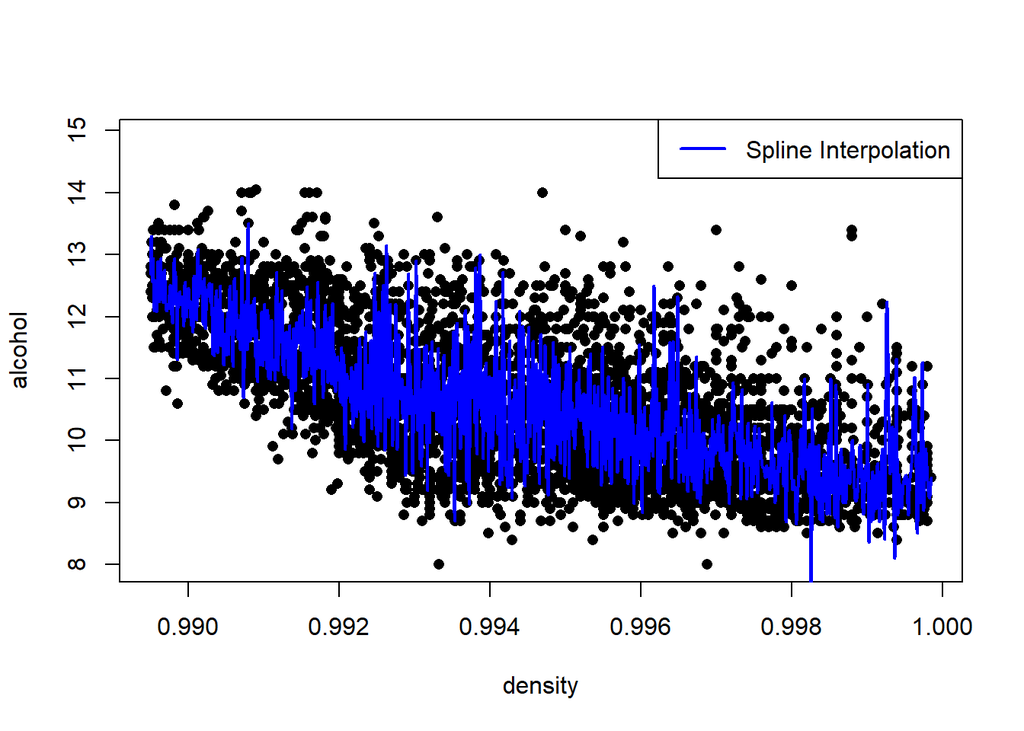

```r
plot(density, alcohol, pch = 16, col="black")
lines(spline_fit, col = "blue",lwd=2)
legend("topright",c("Spline Interpolation"),col=c("blue","purple"),lwd=2)
```

Since spline interpolation passes through every data, the interpolating spline appears to be extremely jagged and not smooth. It has a high degree of variation or roughness. This is often referred to as overfitting, where the spline is too flexible and closely fits the individual data points, but fails to capture the overall trend of the data.

*Comparison between Spline interpolation and Smoothing Splines*

[figure not shown]

```r
#Plotting Regression Line
plot(density,alcohol,col="black")
lines(spline_fit, col = "blue",lwd=2)
lines(fit2,lwd=2,col="red")
legend("topright",c("Smoothing Splines with 10.42245 df selected by CV","Spline Interpolation"),col=c("blue","red"),lwd=2)
```

Comparing both splines, the smoothing spline captures the general trend of the data better than that of the interpolating spline. An interpolating spline is a type of spline that passes through each of the data points exactly, without considering the overall trend of the data. This can lead to a spline that is too jaggered and not smooth, as it closely fits each data point without taking into account the noise or variability in the data.

On the other hand, a smoothing spline is a type of spline that considers both the data points and the overall trend of the data. It does this by adding a smoothing penalty to the spline fit, which discourages the spline from varying too much between neighboring data points. This results in a smoother and more general representation of the data, which captures the overall trend of the data better than that of the interpolating spline.

# 4. Generalized Additive Model (GAMs)

```r
#install.packages('gam')
library(gam)
```

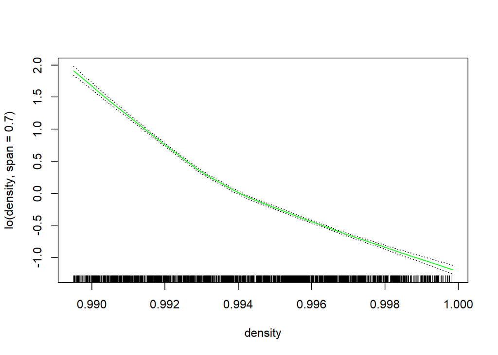

```r
#The lo function is used to model the effect of density using a locally weighted regression smoother, also known as a loess smoother.

gam.lo=gam(alcohol~lo(density ,span =0.7),data=data)
plot.Gam(gam.lo , se=TRUE , col ="green ")#se=TRUE specifying that standard error bands should be included in the plot
```

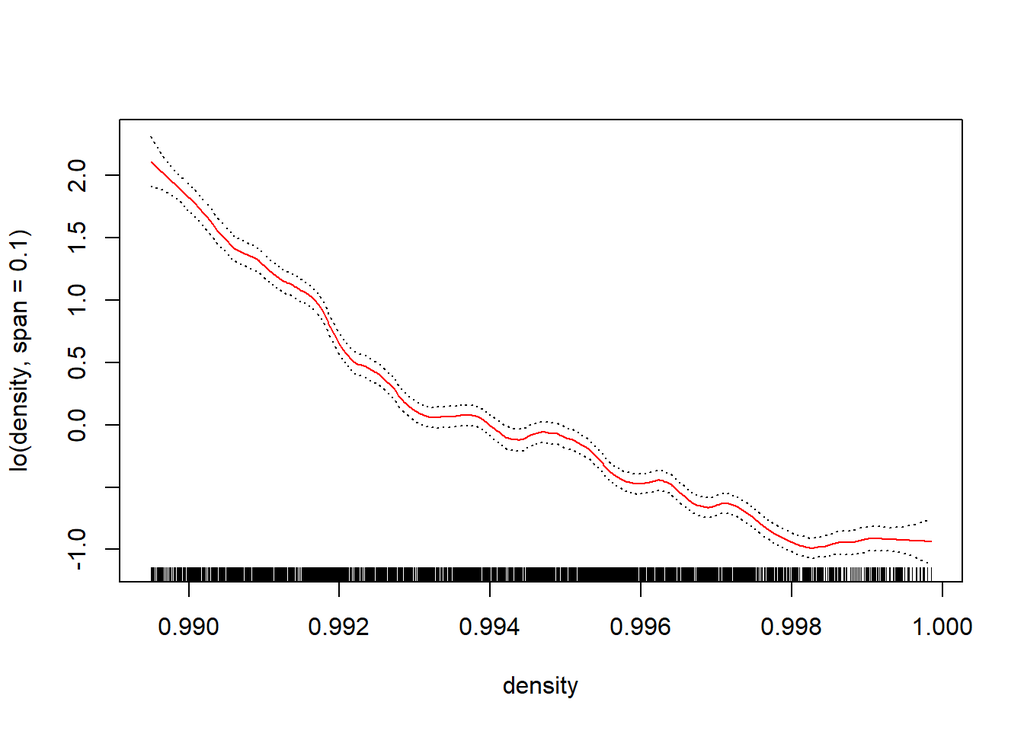

```r
gam.lo2=gam(alcohol~lo(density ,span =0.1),data=data)
plot.Gam(gam.lo2 , se=TRUE , col ="red ")#se=TRUE specifying that standard error bands should be included in the plot
```

Comparing both graphs where the span=0.7 vs span=0.1, the graph with a lower span appears to be less smooth and more flexible. With a larger span, the curve will be relatively smooth and will follow the overall trend of the data, rather than closely fitting each individual data point. A smaller value of span would result in a curve that is more flexible and more closely fits each individual data point. This agrees with the graphs produced, of different span values.

Furthermore, the overall shape of the GAM graph in green agrees with that generated by the Smoothing spline with 10.42245 df. However, it is important to note that the GAM graph is fitted with a loess smoother specified by lo(). In contrast, a smoothing spline typically involves fitting a spline function to the data, with the goal of minimizing the sum of squared residuals while achieving a smooth curve. This method can be more flexible than a LOESS smoother with span=0.7, and may be better suited to capturing more complex or nonlinear relationships between variables.